# Исследование объявлений о продаже квартир

В вашем распоряжении данные сервиса Яндекc Недвижимость — архив объявлений о продаже квартир в Санкт-Петербурге и соседних населённых пунктах за несколько лет. Нужно научиться определять рыночную стоимость объектов недвижимости. Ваша задача — установить параметры. Это позволит построить автоматизированную систему: она отследит аномалии и мошенническую деятельность.

По каждой квартире на продажу доступны два вида данных. Первые вписаны пользователем, вторые получены автоматически на основе картографических данных. Например, расстояние до центра, аэропорта, ближайшего парка и водоёма.

**Цель исследования** - поиск ответов на следующие вопросы:

1. Какие факторы в наибольшей степени влияют на стоимость жилья?
2. В каком населённом пункте самая высокая, а в каком самая низкая стоимость жилья?
3. Отличаются ли факторы, влияющие на ценообразование в центре Санкт-Петербурга от данных по всей таблице?

**Ход исследования**

Исследование пройдёт в четыре этапа:

1. Обзор данных.
2. Предобработка данных.
3. Расчёты и добавление результатов в таблицу
4. Исследовательский анализ данных и поиск ответов на поставленные вопросы.

## 1.Изучение данных из файла

Предварительно ознакомимся с данными из таблицы

```python
import pandas as pd
import matplotlib.pyplot as plt
import warnings
warnings.filterwarnings('ignore')
```

```python
try:
    df = pd.read_csv('real_estate_data.csv', sep='\t')
except:
    df = pd.read_csv('/datasets/real_estate_data.csv', sep='\t')
```

```python
df.head(10)
```

|  | total_images | last_price | total_area | first_day_exposition | rooms | ceiling_height | floors_total | living_area | floor | is_apartment | ... | kitchen_area | balcony | locality_name | airports_nearest | cityCenters_nearest | parks_around3000 | parks_nearest | ponds_around3000 | ponds_nearest | days_exposition |
| --- | --- | --- | --- | --- | --- | --- | --- | --- | --- | --- | --- | --- | --- | --- | --- | --- | --- | --- | --- | --- | --- |
| 0 | 20 | 13000000.0 | 108.00 | 2019-03-07T00:00:00 | 3 | 2.70 | 16.0 | 51.00 | 8 | NaN | ... | 25.00 | NaN | Санкт-Петербург | 18863.0 | 16028.0 | 1.0 | 482.0 | 2.0 | 755.0 | NaN |
| 1 | 7 | 3350000.0 | 40.40 | 2018-12-04T00:00:00 | 1 | NaN | 11.0 | 18.60 | 1 | NaN | ... | 11.00 | 2.0 | посёлок Шушары | 12817.0 | 18603.0 | 0.0 | NaN | 0.0 | NaN | 81.0 |
| 2 | 10 | 5196000.0 | 56.00 | 2015-08-20T00:00:00 | 2 | NaN | 5.0 | 34.30 | 4 | NaN | ... | 8.30 | 0.0 | Санкт-Петербург | 21741.0 | 13933.0 | 1.0 | 90.0 | 2.0 | 574.0 | 558.0 |
| 3 | 0 | 64900000.0 | 159.00 | 2015-07-24T00:00:00 | 3 | NaN | 14.0 | NaN | 9 | NaN | ... | NaN | 0.0 | Санкт-Петербург | 28098.0 | 6800.0 | 2.0 | 84.0 | 3.0 | 234.0 | 424.0 |
| 4 | 2 | 10000000.0 | 100.00 | 2018-06-19T00:00:00 | 2 | 3.03 | 14.0 | 32.00 | 13 | NaN | ... | 41.00 | NaN | Санкт-Петербург | 31856.0 | 8098.0 | 2.0 | 112.0 | 1.0 | 48.0 | 121.0 |
| 5 | 10 | 2890000.0 | 30.40 | 2018-09-10T00:00:00 | 1 | NaN | 12.0 | 14.40 | 5 | NaN | ... | 9.10 | NaN | городской посёлок Янино-1 | NaN | NaN | NaN | NaN | NaN | NaN | 55.0 |
| 6 | 6 | 3700000.0 | 37.30 | 2017-11-02T00:00:00 | 1 | NaN | 26.0 | 10.60 | 6 | NaN | ... | 14.40 | 1.0 | посёлок Парголово | 52996.0 | 19143.0 | 0.0 | NaN | 0.0 | NaN | 155.0 |
| 7 | 5 | 7915000.0 | 71.60 | 2019-04-18T00:00:00 | 2 | NaN | 24.0 | NaN | 22 | NaN | ... | 18.90 | 2.0 | Санкт-Петербург | 23982.0 | 11634.0 | 0.0 | NaN | 0.0 | NaN | NaN |
| 8 | 20 | 2900000.0 | 33.16 | 2018-05-23T00:00:00 | 1 | NaN | 27.0 | 15.43 | 26 | NaN | ... | 8.81 | NaN | посёлок Мурино | NaN | NaN | NaN | NaN | NaN | NaN | 189.0 |
| 9 | 18 | 5400000.0 | 61.00 | 2017-02-26T00:00:00 | 3 | 2.50 | 9.0 | 43.60 | 7 | NaN | ... | 6.50 | 2.0 | Санкт-Петербург | 50898.0 | 15008.0 | 0.0 | NaN | 0.0 | NaN | 289.0 |

10 rows × 22 columns

Также ознакомимся с основными характеристиками датафрейма

```python
df.info()
```

```
<class 'pandas.core.frame.DataFrame'>
RangeIndex: 23699 entries, 0 to 23698
Data columns (total 22 columns):
 #   Column                Non-Null Count  Dtype
---  ------                --------------  -----
 0   total_images          23699 non-null  int64
 1   last_price            23699 non-null  float64
 2   total_area            23699 non-null  float64
 3   first_day_exposition  23699 non-null  object
 4   rooms                 23699 non-null  int64
 5   ceiling_height        14504 non-null  float64
 6   floors_total          23613 non-null  float64
 7   living_area           21796 non-null  float64
 8   floor                 23699 non-null  int64
 9   is_apartment          2775 non-null   object
 10  studio                23699 non-null  bool
 11  open_plan             23699 non-null  bool
 12  kitchen_area          21421 non-null  float64
 13  balcony               12180 non-null  float64
 14  locality_name         23650 non-null  object
 15  airports_nearest      18157 non-null  float64
 16  cityCenters_nearest   18180 non-null  float64
 17  parks_around3000      18181 non-null  float64
 18  parks_nearest         8079 non-null   float64
 19  ponds_around3000      18181 non-null  float64
 20  ponds_nearest         9110 non-null   float64
 21  days_exposition       20518 non-null  float64
dtypes: bool(2), float64(14), int64(3), object(3)
memory usage: 3.7+ MB
```

Согласно документации к данным:

- `airports_nearest` — расстояние до ближайшего аэропорта в метрах (м)
- `balcony` — число балконов
- `ceiling_height` — высота потолков (м)
- `cityCenters_nearest` — расстояние до центра города (м)
- `days_exposition` — сколько дней было размещено объявление (от публикации до снятия)
- `first_day_exposition` — дата публикации
- `floor` — этаж
- `floors_total` — всего этажей в доме
- `is_apartment` — апартаменты (булев тип)
- `kitchen_area` — площадь кухни в квадратных метрах (м²)
- `last_price` — цена на момент снятия с публикации
- `living_area` — жилая площадь в квадратных метрах (м²)
- `locality_name` — название населённого пункта
- `open_plan` — свободная планировка (булев тип)
- `parks_around3000` — число парков в радиусе 3 км
- `parks_nearest` — расстояние до ближайшего парка (м)
- `ponds_around3000` — число водоёмов в радиусе 3 км
- `ponds_nearest` — расстояние до ближайшего водоёма (м)
- `rooms` — число комнат
- `studio` — квартира-студия (булев тип)
- `total_area` — площадь квартиры в квадратных метрах (м²)
- `total_images` — число фотографий квартиры в объявлении

**Вывод**

Предварительно можно утверждать, что, данных достаточно для проверки гипотез.

При этом обзор данных позволил обнаружить несколько проблем:

- В отдельных столбцах есть пропущенные значения
- Присутствуют несоответствия между типом данных и значениям. Например, в столбце `is_apartment` должен быть булев тип данных, а вместо этого - `object`. Также целесообразно перевести значения столбца `first_day_exposition` в формат `datetime`.

Чтобы двигаться дальше, нужно устранить проблемы в данных.

## 2.Предобработка данных

К содержанию

## 2.1 Заполнение пропусков

Пропущенные значения были обнаружены в следующих столбцах: `ceiling_height, floors_total, living_area, is_apartment, kitchen_area, balcony, locality_name, airports_nearest, cityCenters_nearest, parks_around3000, parks_nearest, ponds_around3000, ponds_nearest, days_exposition`.

Доля пропусков в столбцах `floors_total` и `locality_name` крайне незначительна:

```python
print(len(df[df['floors_total'].isna() == True]) / len(df))
len(df[df['locality_name'].isna() == True]) / len(df)
```

```
0.0036288450989493226
```

```
0.002067597788936242
```

В обоих случаях она составляет меньше 1%. Адекватная замена пропущенных значений здесь невозможна. По этой причине для избавления от пропусков целесообразным выглядит удаление соответствующих строк - их отсутствие не должно сильно исказить результаты исследования.

```python
# удаление строк с пропусками
df.dropna(subset=['floors_total', 'locality_name'], inplace=True)
```

```python
# проверка результата
df.info()
```

```
<class 'pandas.core.frame.DataFrame'>
Int64Index: 23565 entries, 0 to 23698
Data columns (total 22 columns):
 #   Column                Non-Null Count  Dtype
---  ------                --------------  -----
 0   total_images          23565 non-null  int64
 1   last_price            23565 non-null  float64
 2   total_area            23565 non-null  float64
 3   first_day_exposition  23565 non-null  object
 4   rooms                 23565 non-null  int64
 5   ceiling_height        14481 non-null  float64
 6   floors_total          23565 non-null  float64
 7   living_area           21700 non-null  float64
 8   floor                 23565 non-null  int64
 9   is_apartment          2760 non-null   object
 10  studio                23565 non-null  bool
 11  open_plan             23565 non-null  bool
 12  kitchen_area          21343 non-null  float64
 13  balcony               12090 non-null  float64
 14  locality_name         23565 non-null  object
 15  airports_nearest      18041 non-null  float64
 16  cityCenters_nearest   18064 non-null  float64
 17  parks_around3000      18065 non-null  float64
 18  parks_nearest         8030 non-null   float64
 19  ponds_around3000      18065 non-null  float64
 20  ponds_nearest         9036 non-null   float64
 21  days_exposition       20394 non-null  float64
dtypes: bool(2), float64(14), int64(3), object(3)
memory usage: 3.8+ MB
```

Пропусков в столбцах `ceiling_height`, `living_area`, `kitchen_area`, `is_apartment` и `balcony` уже значительно больше, поэтому их невозможно удалить без ущерба для качества исследования. Все эти столбцы заполняются вручную самими пользователями.

`is_apartment` - столбец с булевым типом данных, он содержит информацию является ли жилье апартаментами. Можно предположить, что если квартира действительно имеет особый статус, то пользователь отдельно отметит это в объявлении. По этой причине пропуски в этом столбце можно связать с тем, что жилье апартаментами не является, т.к. пользователь явно не указал это в своем объявлении. Тогда оптимальный вариант - это замена всех пропусков на `False`:

```python
# Замена всех пропусков столбца is_apartment на False
df['is_apartment'].fillna(False, inplace=True)
```

```python
# Проверка результата
df['is_apartment'].value_counts()
```

```
False    23515
True        50
Name: is_apartment, dtype: int64
```

Схожая ситуация и со столбцом `balcony` (количество балконов). Раз пользователь явно не указал их количество, то можно предположить, что балконов в его квартире нет вовсе. Раз так, то заполним все пропущенные значения нулями:

```python
# Заполняем нулями пропуски в balcony
df['balcony'].fillna(0, inplace=True)
```

```python
# Проверка результата
df['balcony'].value_counts()
```

```
0.0    15155
1.0     4187
2.0     3656
5.0      304
4.0      182
3.0       81
Name: balcony, dtype: int64
```

Пропуски в `ceiling_height` можно заполнить медианным значением высоты потолков из данного столбца. Однако высота потолков сильно зависит от характеристик конкретной недвижимости. Одним из факторов, влияющих на этот параметр является этажность здания. По этой причине, чтобы чрезмерно не усреднять данные и меньше повлиять на итоговое распределение, заполним пропуски медианными значениями, расчитанными в зависимости от этажности конкретного дома.

Для начала проверим, насколько корректно расчитываются медианы для домов в разной этажностью:

```python
# создаем сводную таблицу медианных значений высоты потолков в зависимости от этажности
floors_pivot = df.pivot_table(index='floors_total', values='ceiling_height', aggfunc='median')
floors_pivot
```

| floors_total | ceiling_height |
| --- | --- |
| 1.0 | 2.80 |
| 2.0 | 2.70 |
| 3.0 | 2.80 |
| 4.0 | 3.00 |
| 5.0 | 2.55 |
| 6.0 | 3.00 |
| 7.0 | 3.00 |
| 8.0 | 2.80 |
| 9.0 | 2.55 |
| 10.0 | 2.60 |
| 11.0 | 2.75 |
| 12.0 | 2.65 |
| 13.0 | 2.70 |
| 14.0 | 2.60 |
| 15.0 | 2.70 |
| 16.0 | 2.70 |
| 17.0 | 2.70 |
| 18.0 | 2.70 |
| 19.0 | 2.75 |
| 20.0 | 2.75 |
| 21.0 | 2.70 |
| 22.0 | 2.75 |
| 23.0 | 2.75 |
| 24.0 | 2.75 |
| 25.0 | 2.75 |
| 26.0 | 2.66 |
| 27.0 | 2.70 |
| 28.0 | 2.60 |
| 29.0 | 2.60 |
| 34.0 | 2.65 |
| 35.0 | 2.70 |
| 36.0 | 14.85 |
| 37.0 | 1.75 |
| 52.0 | 2.65 |
| 60.0 | 2.88 |

Привлекает внимание странное значение для 36-этажных домов. Взглянем на эти чудо-квартиры подробнее:

```python
df.query('floors_total == 36')
```

|  | total_images | last_price | total_area | first_day_exposition | rooms | ceiling_height | floors_total | living_area | floor | is_apartment | ... | kitchen_area | balcony | locality_name | airports_nearest | cityCenters_nearest | parks_around3000 | parks_nearest | ponds_around3000 | ponds_nearest | days_exposition |
| --- | --- | --- | --- | --- | --- | --- | --- | --- | --- | --- | --- | --- | --- | --- | --- | --- | --- | --- | --- | --- | --- |
| 397 | 15 | 5990000.0 | 54.0 | 2018-03-22T00:00:00 | 2 | NaN | 36.0 | 21.4 | 28 | False | ... | 18.7 | 1.0 | Санкт-Петербург | 18732.0 | 20444.0 | 0.0 | NaN | 3.0 | 80.0 | 11.0 |
| 5807 | 17 | 8150000.0 | 80.0 | 2019-01-09T00:00:00 | 2 | 27.0 | 36.0 | 41.0 | 13 | False | ... | 12.0 | 5.0 | Санкт-Петербург | 18732.0 | 20444.0 | 0.0 | NaN | 3.0 | 80.0 | 38.0 |
| 11079 | 16 | 9200000.0 | 75.0 | 2019-02-22T00:00:00 | 2 | 2.7 | 36.0 | 40.0 | 29 | False | ... | 12.0 | 2.0 | Санкт-Петербург | 18732.0 | 20444.0 | 0.0 | NaN | 3.0 | 80.0 | NaN |

3 rows × 22 columns

В срезе всего 2 дома без пропущенных значений, поэтому медиана - это среднее арифметическое от обычного и явно завышенного значения. Судя по всему здесь произошла опечатка, и точку поставили не в том месте.

Поэтому заменим "битое" значение на 2.7:

```python
df.loc[5807, 'ceiling_height'] = 2.7
```

```python
# Заполняем пропуски медианным значеним высоты потолков, в зависимости от этажности здания
df['ceiling_height'].fillna(df.groupby(by='floors_total')['ceiling_height'].transform('median'), inplace=True)
```

```python
# Проверка успешности операции
df['ceiling_height'].isna().sum()
```

```
1
```

Остался один пропуск, видимо данных для рассчета медианы не хватило, оставшееся значение заполним медианой высоты потолков, расчитанной по всем квартирам из таблицы

```python
df['ceiling_height'].fillna(df['ceiling_height'].median(), inplace=True)
```

```python
# Заключительная (надеюсь) проверка
df['ceiling_height'].isna().sum()
```

```
0
```

Жилая площадь квартиры в столбце `living_area` также зависит от других переменных, в частности от общей площади жилья. Поэтому пропуски в этом столбце можно заполнить средним соотношением жилой площади `living_area` к общей площади квартиры `total_area`:

```python
# Переменная соотношения жилой площади к общей
area_ratio =  df['living_area'].mean() / df['total_area'].mean()
area_ratio
```

```
0.571173883860645
```

```python
# Заполнение пропусков полученным соотношением
df['living_area'].fillna(df['total_area'] * area_ratio, inplace=True)
```

```python
# Проверка результата
df['living_area'].isna().sum()
```

```
0
```

Аналогичную операцию проделаем и со столбцом `kitchen_area`. Однако здесь площадь кухни зависит не только от общей площади квартиры, но и от того, сколько в ней комнат - например, в студии кухни может не быть вовсе.

Проверим есть ли у студий заполненные значения для `kitchen_area`

```python
# Количество студий
len(df[df['studio'] == True])
```

```
146
```

```python
# Проверка пропущенных значений  в kitchen_area для квартир-студий
df[df['studio'] == True]['kitchen_area'].isna().sum()
```

```
146
```

Действительно, во всех студиях не указана площадь кухни. По этой причине, заполним пропуски средним соотношением площади кухни `kitchen_area` к общей площади `total_area`, для всех квартир кроме тех, которые являются студиями. Для них заменим пропуски нулями

```python
# Переменная соотношения площади кухни к общей площади квартиры
kitchen_ratio = df['kitchen_area'].mean() / df['total_area'].mean()
kitchen_ratio
```

```
0.17507459894216174
```

```python
# Заполнение пропусков для всех квартир полученным соотношением
df['kitchen_area'].fillna(df['total_area'] * kitchen_ratio, inplace=True)
```

```python
# Присваивание студиям площади кухни равной нулю
df['kitchen_area'].where(df['studio'] == False, 0, inplace=True)
```

```python
# Проверка на пустые значения
df['kitchen_area'].isna().sum()
```

```
0
```

```python
# Проверка значений kitchen_area отдельно для студий
df.query('studio == True').head()
```

|  | total_images | last_price | total_area | first_day_exposition | rooms | ceiling_height | floors_total | living_area | floor | is_apartment | ... | kitchen_area | balcony | locality_name | airports_nearest | cityCenters_nearest | parks_around3000 | parks_nearest | ponds_around3000 | ponds_nearest | days_exposition |
| --- | --- | --- | --- | --- | --- | --- | --- | --- | --- | --- | --- | --- | --- | --- | --- | --- | --- | --- | --- | --- | --- |
| 144 | 1 | 2450000.0 | 27.00 | 2017-03-30T00:00:00 | 0 | 2.75 | 24.0 | 15.500000 | 2 | False | ... | 0.0 | 2.0 | посёлок Мурино | NaN | NaN | NaN | NaN | NaN | NaN | 181.0 |
| 440 | 8 | 2480000.0 | 27.11 | 2018-03-12T00:00:00 | 0 | 2.70 | 17.0 | 24.750000 | 4 | False | ... | 0.0 | 2.0 | Санкт-Петербург | 38171.0 | 15015.0 | 0.0 | NaN | 2.0 | 982.0 | 64.0 |
| 608 | 2 | 1850000.0 | 25.00 | 2019-02-20T00:00:00 | 0 | 2.60 | 10.0 | 14.279347 | 7 | False | ... | 0.0 | 0.0 | посёлок Шушары | NaN | NaN | NaN | NaN | NaN | NaN | 29.0 |
| 697 | 12 | 2500000.0 | 24.10 | 2017-12-01T00:00:00 | 0 | 2.75 | 25.0 | 17.500000 | 21 | False | ... | 0.0 | 0.0 | деревня Кудрово | NaN | NaN | NaN | NaN | NaN | NaN | 201.0 |
| 716 | 5 | 1500000.0 | 17.00 | 2017-06-07T00:00:00 | 0 | 2.70 | 9.0 | 12.000000 | 1 | False | ... | 0.0 | 0.0 | посёлок Шушары | 18654.0 | 29846.0 | 0.0 | NaN | 0.0 | NaN | 40.0 |

5 rows × 22 columns

Столбец `days_exposition` содержит информацию о том, сколько дней было размещено объявление (от публикации до снятия). Пропуски здесь могут быть из-за того, что объявление действующее и еще не было снято с показа. Поэтому пропуски в этом столбце оставим без изменений.

Данные в столбцах `airports_nearest`, `cityCenters_nearest`, `parks_around3000`, `parks_nearest`, `ponds_around3000`, `ponds_nearest`, получены автоматически на основе картографических данных.

Проверим существует ли взаимосвязь между пропусками в этих столбцах. Для начала посмотрим на столбец `airports_nearest`:

```python
df.query('airports_nearest.isna() == True', engine='python').head(10)
```

|  | total_images | last_price | total_area | first_day_exposition | rooms | ceiling_height | floors_total | living_area | floor | is_apartment | ... | kitchen_area | balcony | locality_name | airports_nearest | cityCenters_nearest | parks_around3000 | parks_nearest | ponds_around3000 | ponds_nearest | days_exposition |
| --- | --- | --- | --- | --- | --- | --- | --- | --- | --- | --- | --- | --- | --- | --- | --- | --- | --- | --- | --- | --- | --- |
| 5 | 10 | 2890000.0 | 30.40 | 2018-09-10T00:00:00 | 1 | 2.65 | 12.0 | 14.400000 | 5 | False | ... | 9.100000 | 0.0 | городской посёлок Янино-1 | NaN | NaN | NaN | NaN | NaN | NaN | 55.0 |
| 8 | 20 | 2900000.0 | 33.16 | 2018-05-23T00:00:00 | 1 | 2.70 | 27.0 | 15.430000 | 26 | False | ... | 8.810000 | 0.0 | посёлок Мурино | NaN | NaN | NaN | NaN | NaN | NaN | 189.0 |
| 12 | 10 | 3890000.0 | 54.00 | 2016-06-30T00:00:00 | 2 | 2.55 | 5.0 | 30.000000 | 5 | False | ... | 9.000000 | 0.0 | Сертолово | NaN | NaN | NaN | NaN | NaN | NaN | 90.0 |
| 22 | 20 | 5000000.0 | 58.00 | 2017-04-24T00:00:00 | 2 | 2.75 | 25.0 | 30.000000 | 15 | False | ... | 11.000000 | 2.0 | деревня Кудрово | NaN | NaN | NaN | NaN | NaN | NaN | 60.0 |
| 30 | 12 | 2200000.0 | 32.80 | 2018-02-19T00:00:00 | 1 | 2.55 | 9.0 | 18.734503 | 2 | False | ... | 5.742447 | 0.0 | Коммунар | NaN | NaN | NaN | NaN | NaN | NaN | 63.0 |
| 37 | 10 | 1990000.0 | 45.80 | 2017-10-28T00:00:00 | 2 | 2.50 | 5.0 | 26.159764 | 1 | False | ... | 8.018417 | 0.0 | поселок городского типа Красный Бор | NaN | NaN | NaN | NaN | NaN | NaN | 196.0 |
| 38 | 10 | 3150000.0 | 40.00 | 2018-03-29T00:00:00 | 1 | 2.75 | 18.0 | 16.300000 | 9 | False | ... | 11.600000 | 0.0 | посёлок Мурино | NaN | NaN | NaN | NaN | NaN | NaN | 103.0 |
| 47 | 17 | 3600000.0 | 56.10 | 2018-10-18T00:00:00 | 3 | 3.00 | 4.0 | 42.500000 | 3 | False | ... | 5.700000 | 1.0 | Гатчина | NaN | NaN | NaN | NaN | NaN | NaN | 179.0 |
| 60 | 3 | 2740000.0 | 35.00 | 2018-01-01T00:00:00 | 1 | 2.65 | 12.0 | 19.991086 | 8 | False | ... | 6.127611 | 0.0 | посёлок Мурино | NaN | NaN | NaN | NaN | NaN | NaN | 11.0 |
| 62 | 0 | 4800000.0 | 78.60 | 2017-09-17T00:00:00 | 3 | 2.80 | 9.0 | 48.800000 | 5 | False | ... | 11.900000 | 2.0 | Сертолово | NaN | NaN | NaN | NaN | NaN | NaN | 5.0 |

10 rows × 22 columns

Как мы видим присутствуют одновременные пропуски во всех вышеобозначанных столбцах. Можно обнаружить закономерность - почти во всех случаях пропуски наблюдаются вне Санкт-Петербурга. Возможно данные в столбцах автоматически расчитываются только для этого города, а в остальных случаях возникают пропуски.

Проверим, правда ли это так:

```python
# Создаем список data - с названиями нужных столбцов
# Проверяем долю пропусков вне Санкт-Петербурга
data = ['airports_nearest', 'cityCenters_nearest', 'parks_around3000', 'parks_nearest', 'ponds_around3000', 'ponds_nearest']
for column in data:
    print(f'{column}:',
          len(df[(df[column].isna() == True) &
                 (df['locality_name'] != 'Санкт-Петербург')]),
          'из', len(df[df[column].isna() == True]))
```

```
airports_nearest: 5440 из 5524
cityCenters_nearest: 5441 из 5501
parks_around3000: 5440 из 5500
parks_nearest: 7135 из 15535
ponds_around3000: 5440 из 5500
ponds_nearest: 6814 из 14529
```

Тем не менее, пропуски присутствуют и в данных, связанных с квартирами в Питере:

```python
# Проверяем  пропуски в черте Санкт-Петербурга
for column in data:
    print(f'{column}:',
          len(df[(df[column].isna() == True) &
                 (df['locality_name'] == 'Санкт-Петербург')]),
          'из', len(df[df[column].isna() == True]))
```

```
airports_nearest: 84 из 5524
cityCenters_nearest: 60 из 5501
parks_around3000: 60 из 5500
parks_nearest: 8400 из 15535
ponds_around3000: 60 из 5500
ponds_nearest: 7715 из 14529
```

Наиболее критичными для исследования являются пропуски в столбце `cityCenters_nearest`, так как с ним связана одна из последующих задач.

Для начала проверим среднее значенее и медиану для этих столбцов:

```python
df['cityCenters_nearest'].describe()
```

```
count    18064.000000
mean     14192.656056
std       8613.348153
min        181.000000
25%       9238.000000
50%      13096.500000
75%      16285.000000
max      65968.000000
Name: cityCenters_nearest, dtype: float64
```

```python
df[df['cityCenters_nearest'].isna()].head(10)
```

|  | total_images | last_price | total_area | first_day_exposition | rooms | ceiling_height | floors_total | living_area | floor | is_apartment | ... | kitchen_area | balcony | locality_name | airports_nearest | cityCenters_nearest | parks_around3000 | parks_nearest | ponds_around3000 | ponds_nearest | days_exposition |
| --- | --- | --- | --- | --- | --- | --- | --- | --- | --- | --- | --- | --- | --- | --- | --- | --- | --- | --- | --- | --- | --- |
| 5 | 10 | 2890000.0 | 30.40 | 2018-09-10T00:00:00 | 1 | 2.65 | 12.0 | 14.400000 | 5 | False | ... | 9.100000 | 0.0 | городской посёлок Янино-1 | NaN | NaN | NaN | NaN | NaN | NaN | 55.0 |
| 8 | 20 | 2900000.0 | 33.16 | 2018-05-23T00:00:00 | 1 | 2.70 | 27.0 | 15.430000 | 26 | False | ... | 8.810000 | 0.0 | посёлок Мурино | NaN | NaN | NaN | NaN | NaN | NaN | 189.0 |
| 12 | 10 | 3890000.0 | 54.00 | 2016-06-30T00:00:00 | 2 | 2.55 | 5.0 | 30.000000 | 5 | False | ... | 9.000000 | 0.0 | Сертолово | NaN | NaN | NaN | NaN | NaN | NaN | 90.0 |
| 22 | 20 | 5000000.0 | 58.00 | 2017-04-24T00:00:00 | 2 | 2.75 | 25.0 | 30.000000 | 15 | False | ... | 11.000000 | 2.0 | деревня Кудрово | NaN | NaN | NaN | NaN | NaN | NaN | 60.0 |
| 30 | 12 | 2200000.0 | 32.80 | 2018-02-19T00:00:00 | 1 | 2.55 | 9.0 | 18.734503 | 2 | False | ... | 5.742447 | 0.0 | Коммунар | NaN | NaN | NaN | NaN | NaN | NaN | 63.0 |
| 37 | 10 | 1990000.0 | 45.80 | 2017-10-28T00:00:00 | 2 | 2.50 | 5.0 | 26.159764 | 1 | False | ... | 8.018417 | 0.0 | поселок городского типа Красный Бор | NaN | NaN | NaN | NaN | NaN | NaN | 196.0 |
| 38 | 10 | 3150000.0 | 40.00 | 2018-03-29T00:00:00 | 1 | 2.75 | 18.0 | 16.300000 | 9 | False | ... | 11.600000 | 0.0 | посёлок Мурино | NaN | NaN | NaN | NaN | NaN | NaN | 103.0 |
| 47 | 17 | 3600000.0 | 56.10 | 2018-10-18T00:00:00 | 3 | 3.00 | 4.0 | 42.500000 | 3 | False | ... | 5.700000 | 1.0 | Гатчина | NaN | NaN | NaN | NaN | NaN | NaN | 179.0 |
| 60 | 3 | 2740000.0 | 35.00 | 2018-01-01T00:00:00 | 1 | 2.65 | 12.0 | 19.991086 | 8 | False | ... | 6.127611 | 0.0 | посёлок Мурино | NaN | NaN | NaN | NaN | NaN | NaN | 11.0 |
| 62 | 0 | 4800000.0 | 78.60 | 2017-09-17T00:00:00 | 3 | 2.80 | 9.0 | 48.800000 | 5 | False | ... | 11.900000 | 2.0 | Сертолово | NaN | NaN | NaN | NaN | NaN | NaN | 5.0 |

10 rows × 22 columns

```python
# пишем функцию для медианы и замены пропусков
df['cityCenters_nearest'].fillna(df.groupby(by='locality_name')['cityCenters_nearest'].transform('mean'), inplace=True)
```

```python
# Проверка
df['cityCenters_nearest'].isna().sum()
```

```
5432
```

Как видим, даже после выполнения операции в столбце по-прежнему присутствует большое количество пропусков. Чтобы лучше понять их природу, сравним списки населенных пунктов с пропусками в `cityCenters_nearest` и без них

```python
# Список населенных пунктов без пропущенных значений
df[df['cityCenters_nearest'].isna() == False]['locality_name'].value_counts()
```

```
Санкт-Петербург            15651
посёлок Шушары               439
Пушкин                       369
Колпино                      338
посёлок Парголово            327
Петергоф                     201
Сестрорецк                   183
Красное Село                 176
Ломоносов                    133
Кронштадт                     96
посёлок Металлострой          66
посёлок Стрельна              43
Павловск                      38
Зеленогорск                   24
посёлок Понтонный             20
посёлок Сапёрный               6
посёлок Молодёжное             5
посёлок Песочный               4
посёлок Репино                 4
посёлок Александровская        2
посёлок Лисий Нос              2
посёлок Усть-Ижора             2
посёлок Петро-Славянка         1
поселок Лисий Нос              1
посёлок Левашово               1
посёлок Белоостров             1
Name: locality_name, dtype: int64
```

```python
# Список населенных пунктов с пропусками
df[df['cityCenters_nearest'].isna() == True]['locality_name'].value_counts()
```

```
посёлок Мурино                     520
Всеволожск                         398
Гатчина                            307
деревня Кудрово                    299
Выборг                             237
                                  ...
посёлок Алексеевка                   1
деревня Пельгора                     1
поселок Каложицы                     1
посёлок Платформа 69-й километр      1
посёлок Дзержинского                 1
Name: locality_name, Length: 338, dtype: int64
```

Можно обнаружить закономерность: большинство населенных пунктов без пропусков входят в административные границы Санкт-Петербурга, пропуски в основном наблюдаются уже за пределами Северной столицы. Видимо, в столбце `cityCenters_nearest` содержится расстояние до центра именно Санкт-петербурга.

В такой ситуации расстояние до центра сложно заменить каким-либо значеним, адекватно отражающем действительность. Поэтому сохраним оставшиеся пропущенные значения - они будут сигналом того, что информация об расстоянии до центра отсутствует, по причине того, что насленный пункт находится на большом удалении от Санкт-Петербурга.

```python
df[df['airports_nearest'].isna()].head(10)
```

|  | total_images | last_price | total_area | first_day_exposition | rooms | ceiling_height | floors_total | living_area | floor | is_apartment | ... | kitchen_area | balcony | locality_name | airports_nearest | cityCenters_nearest | parks_around3000 | parks_nearest | ponds_around3000 | ponds_nearest | days_exposition |
| --- | --- | --- | --- | --- | --- | --- | --- | --- | --- | --- | --- | --- | --- | --- | --- | --- | --- | --- | --- | --- | --- |
| 5 | 10 | 2890000.0 | 30.40 | 2018-09-10T00:00:00 | 1 | 2.65 | 12.0 | 14.400000 | 5 | False | ... | 9.100000 | 0.0 | городской посёлок Янино-1 | NaN | NaN | NaN | NaN | NaN | NaN | 55.0 |
| 8 | 20 | 2900000.0 | 33.16 | 2018-05-23T00:00:00 | 1 | 2.70 | 27.0 | 15.430000 | 26 | False | ... | 8.810000 | 0.0 | посёлок Мурино | NaN | NaN | NaN | NaN | NaN | NaN | 189.0 |
| 12 | 10 | 3890000.0 | 54.00 | 2016-06-30T00:00:00 | 2 | 2.55 | 5.0 | 30.000000 | 5 | False | ... | 9.000000 | 0.0 | Сертолово | NaN | NaN | NaN | NaN | NaN | NaN | 90.0 |
| 22 | 20 | 5000000.0 | 58.00 | 2017-04-24T00:00:00 | 2 | 2.75 | 25.0 | 30.000000 | 15 | False | ... | 11.000000 | 2.0 | деревня Кудрово | NaN | NaN | NaN | NaN | NaN | NaN | 60.0 |
| 30 | 12 | 2200000.0 | 32.80 | 2018-02-19T00:00:00 | 1 | 2.55 | 9.0 | 18.734503 | 2 | False | ... | 5.742447 | 0.0 | Коммунар | NaN | NaN | NaN | NaN | NaN | NaN | 63.0 |
| 37 | 10 | 1990000.0 | 45.80 | 2017-10-28T00:00:00 | 2 | 2.50 | 5.0 | 26.159764 | 1 | False | ... | 8.018417 | 0.0 | поселок городского типа Красный Бор | NaN | NaN | NaN | NaN | NaN | NaN | 196.0 |
| 38 | 10 | 3150000.0 | 40.00 | 2018-03-29T00:00:00 | 1 | 2.75 | 18.0 | 16.300000 | 9 | False | ... | 11.600000 | 0.0 | посёлок Мурино | NaN | NaN | NaN | NaN | NaN | NaN | 103.0 |
| 47 | 17 | 3600000.0 | 56.10 | 2018-10-18T00:00:00 | 3 | 3.00 | 4.0 | 42.500000 | 3 | False | ... | 5.700000 | 1.0 | Гатчина | NaN | NaN | NaN | NaN | NaN | NaN | 179.0 |
| 60 | 3 | 2740000.0 | 35.00 | 2018-01-01T00:00:00 | 1 | 2.65 | 12.0 | 19.991086 | 8 | False | ... | 6.127611 | 0.0 | посёлок Мурино | NaN | NaN | NaN | NaN | NaN | NaN | 11.0 |
| 62 | 0 | 4800000.0 | 78.60 | 2017-09-17T00:00:00 | 3 | 2.80 | 9.0 | 48.800000 | 5 | False | ... | 11.900000 | 2.0 | Сертолово | NaN | NaN | NaN | NaN | NaN | NaN | 5.0 |

10 rows × 22 columns

Пропущенным значениям в столбцах `airports_nearest`, `parks_around3000`, `parks_nearest`, `ponds_around3000`, `ponds_nearest` также трудно подобрать адкватную замену.

Учитывая, что данные из этих столбцов не используются для дальнейшего решения задач исследования, можно просто удалить их из исходного датафрейма

```python
# Удаление столбцов
df.drop(columns=['airports_nearest', 'parks_around3000', 'parks_nearest', 'ponds_around3000', 'ponds_nearest'], inplace=True)
```

```python
# Сброс индексов
df.reset_index(drop=True, inplace=True)
```

```python
# Проверка результата
df.info()
```

```
<class 'pandas.core.frame.DataFrame'>
RangeIndex: 23565 entries, 0 to 23564
Data columns (total 17 columns):
 #   Column                Non-Null Count  Dtype
---  ------                --------------  -----
 0   total_images          23565 non-null  int64
 1   last_price            23565 non-null  float64
 2   total_area            23565 non-null  float64
 3   first_day_exposition  23565 non-null  object
 4   rooms                 23565 non-null  int64
 5   ceiling_height        23565 non-null  float64
 6   floors_total          23565 non-null  float64
 7   living_area           23565 non-null  float64
 8   floor                 23565 non-null  int64
 9   is_apartment          23565 non-null  bool
 10  studio                23565 non-null  bool
 11  open_plan             23565 non-null  bool
 12  kitchen_area          23565 non-null  float64
 13  balcony               23565 non-null  float64
 14  locality_name         23565 non-null  object
 15  cityCenters_nearest   18133 non-null  float64
 16  days_exposition       20394 non-null  float64
dtypes: bool(3), float64(9), int64(3), object(2)
memory usage: 2.6+ MB
```

**Вывод**

Пропущенные значения были обнаружены в следующих столбцах: `ceiling_height, floors_total, living_area, is_apartment, kitchen_area, balcony, locality_name, airports_nearest, cityCenters_nearest, parks_around3000, parks_nearest, ponds_around3000, ponds_nearest, days_exposition`.

## 2.2 Изменение типов данных

К содержанию

Еще раз взглянем на информацию о датафрейме

```python
df.info()
```

```
<class 'pandas.core.frame.DataFrame'>
RangeIndex: 23565 entries, 0 to 23564
Data columns (total 17 columns):
 #   Column                Non-Null Count  Dtype
---  ------                --------------  -----
 0   total_images          23565 non-null  int64
 1   last_price            23565 non-null  float64
 2   total_area            23565 non-null  float64
 3   first_day_exposition  23565 non-null  object
 4   rooms                 23565 non-null  int64
 5   ceiling_height        23565 non-null  float64
 6   floors_total          23565 non-null  float64
 7   living_area           23565 non-null  float64
 8   floor                 23565 non-null  int64
 9   is_apartment          23565 non-null  bool
 10  studio                23565 non-null  bool
 11  open_plan             23565 non-null  bool
 12  kitchen_area          23565 non-null  float64
 13  balcony               23565 non-null  float64
 14  locality_name         23565 non-null  object
 15  cityCenters_nearest   18133 non-null  float64
 16  days_exposition       20394 non-null  float64
dtypes: bool(3), float64(9), int64(3), object(2)
memory usage: 2.6+ MB
```

Можно обнаружить несоответствия типов данных в следующих столбцах:

```python
# Переводим значения столбца в bool
df['is_apartment'] = df['is_apartment'].astype('bool')
```

```python
# Меняем тип данных на datetime
df['first_day_exposition'] = pd.to_datetime(df['first_day_exposition'], format='%Y-%m-%dT%H:%M:%S')
```

```python
# Меняем тип данных на int64
df[['floors_total', 'balcony']] = df[['floors_total', 'balcony']].astype('int')
```

```python
# Проверяем результат
df.info()
```

```
<class 'pandas.core.frame.DataFrame'>
RangeIndex: 23565 entries, 0 to 23564
Data columns (total 17 columns):
 #   Column                Non-Null Count  Dtype
---  ------                --------------  -----
 0   total_images          23565 non-null  int64
 1   last_price            23565 non-null  float64
 2   total_area            23565 non-null  float64
 3   first_day_exposition  23565 non-null  datetime64[ns]
 4   rooms                 23565 non-null  int64
 5   ceiling_height        23565 non-null  float64
 6   floors_total          23565 non-null  int64
 7   living_area           23565 non-null  float64
 8   floor                 23565 non-null  int64
 9   is_apartment          23565 non-null  bool
 10  studio                23565 non-null  bool
 11  open_plan             23565 non-null  bool
 12  kitchen_area          23565 non-null  float64
 13  balcony               23565 non-null  int64
 14  locality_name         23565 non-null  object
 15  cityCenters_nearest   18133 non-null  float64
 16  days_exposition       20394 non-null  float64
dtypes: bool(3), datetime64[ns](1), float64(7), int64(5), object(1)
memory usage: 2.6+ MB
```

**Вывод**

В результате выполнения этого шага данные в столбцах приведены к наиболее удобному для решения последующих задач значению:

- `is_apartment` - превращен из `object` в `bool`, поскольку задача этого столбца - ответить на вопрос является ли квартира апартаментами.
- `first_day_exposition` - переведен в `datetime`, посокольку исходная строка содержала в себе конкретную дату подачи объявления.
- `floors_total`, `balcony` - переведены из `float64` в `int64`, так как в них присутствуют только целые числа.

## 3.Расчёты и добавление результатов в таблицу

## 3.1 Расчет цены квадратного метра

К содержанию

Для последующего выявления факторов, влияющих на стоимость жилья, и адекватного сравнения квартир с разной площадью необходим универсальный показатель цены. Таким показателем является стоимость квадратного метра жилплощади.

Стоимость квадратного метра расчитывается по формуле - стоимость квартиры/площадь квартиры

Добавим в датафрейм новый столбец с результатом операции `last_price/total_area`

```python
# Добавление столбца с ценой за кв. метр
df['sqr_m_price'] = df['last_price'] / df['total_area']
```

```python
# Проверка результата
df.head()
```

|  | total_images | last_price | total_area | first_day_exposition | rooms | ceiling_height | floors_total | living_area | floor | is_apartment | studio | open_plan | kitchen_area | balcony | locality_name | cityCenters_nearest | days_exposition | sqr_m_price |
| --- | --- | --- | --- | --- | --- | --- | --- | --- | --- | --- | --- | --- | --- | --- | --- | --- | --- | --- |
| 0 | 20 | 13000000.0 | 108.0 | 2019-03-07 | 3 | 2.70 | 16 | 51.000000 | 8 | False | False | False | 25.000000 | 0 | Санкт-Петербург | 16028.0 | NaN | 120370.370370 |
| 1 | 7 | 3350000.0 | 40.4 | 2018-12-04 | 1 | 2.75 | 11 | 18.600000 | 1 | False | False | False | 11.000000 | 2 | посёлок Шушары | 18603.0 | 81.0 | 82920.792079 |
| 2 | 10 | 5196000.0 | 56.0 | 2015-08-20 | 2 | 2.55 | 5 | 34.300000 | 4 | False | False | False | 8.300000 | 0 | Санкт-Петербург | 13933.0 | 558.0 | 92785.714286 |
| 3 | 0 | 64900000.0 | 159.0 | 2015-07-24 | 3 | 2.60 | 14 | 90.816648 | 9 | False | False | False | 27.836861 | 0 | Санкт-Петербург | 6800.0 | 424.0 | 408176.100629 |
| 4 | 2 | 10000000.0 | 100.0 | 2018-06-19 | 2 | 3.03 | 14 | 32.000000 | 13 | False | False | False | 41.000000 | 0 | Санкт-Петербург | 8098.0 | 121.0 | 100000.000000 |

**Вывод**

Для решения задач исследования в таблицу добавлен новый столбец `sqr_m_price` с ценой квадратного метра. Благодаря этому стало возможным адекватное сравнение квартир с различной площадью.

## 3.2 Добавление в таблицу дня недели, месяца и года публикации объявления

К содержанию

Для ответа на один из вопросов исследования, требуется информация о дне недели, месяца и года публикации объявления.

Добавим в датафрейм дополнительные столбцы с этой информацией

```python
# Добавление дня недели
df['weekday'] = df['first_day_exposition'].dt.weekday
```

```python
# Добавление месяца
df['month'] = df['first_day_exposition'].dt.month
```

```python
# Добавление года
df['year'] = df['first_day_exposition'].dt.year
```

```python
# Проверка результата
df.head()
```

|  | total_images | last_price | total_area | first_day_exposition | rooms | ceiling_height | floors_total | living_area | floor | is_apartment | ... | open_plan | kitchen_area | balcony | locality_name | cityCenters_nearest | days_exposition | sqr_m_price | weekday | month | year |
| --- | --- | --- | --- | --- | --- | --- | --- | --- | --- | --- | --- | --- | --- | --- | --- | --- | --- | --- | --- | --- | --- |
| 0 | 20 | 13000000.0 | 108.0 | 2019-03-07 | 3 | 2.70 | 16 | 51.000000 | 8 | False | ... | False | 25.000000 | 0 | Санкт-Петербург | 16028.0 | NaN | 120370.370370 | 3 | 3 | 2019 |
| 1 | 7 | 3350000.0 | 40.4 | 2018-12-04 | 1 | 2.75 | 11 | 18.600000 | 1 | False | ... | False | 11.000000 | 2 | посёлок Шушары | 18603.0 | 81.0 | 82920.792079 | 1 | 12 | 2018 |
| 2 | 10 | 5196000.0 | 56.0 | 2015-08-20 | 2 | 2.55 | 5 | 34.300000 | 4 | False | ... | False | 8.300000 | 0 | Санкт-Петербург | 13933.0 | 558.0 | 92785.714286 | 3 | 8 | 2015 |
| 3 | 0 | 64900000.0 | 159.0 | 2015-07-24 | 3 | 2.60 | 14 | 90.816648 | 9 | False | ... | False | 27.836861 | 0 | Санкт-Петербург | 6800.0 | 424.0 | 408176.100629 | 4 | 7 | 2015 |
| 4 | 2 | 10000000.0 | 100.0 | 2018-06-19 | 2 | 3.03 | 14 | 32.000000 | 13 | False | ... | False | 41.000000 | 0 | Санкт-Петербург | 8098.0 | 121.0 | 100000.000000 | 1 | 6 | 2018 |

5 rows × 21 columns

**Вывод**

По результатам данного шага в таблицу были добавлены столбцы `weekday`, `month` и `year`, содержащие в себе информацию о дне недели, месяце и годе, когда было размещено объявление. Данные этих столбцов в дальнейшем понадобятся для определения факторов, влияющих на стоимость недвижимости.

## 3.3. Добавление в таблицу столбца с этажом квартиры

К содержанию

Для проверки гипотезы о зависимости цены от того, на каком этаже расположена квартира, необходимо добавить еще один столбец, в котором каждой квартире будет присвоена соответствующая категория: **первый**, **последний** или **другой**

```python
# Функция присваивающая квартире категорию, в зависимости от этажа
def floor_category(row):
    if row['floor'] == 1:
        return 'first'
    elif row['floor'] == row['floors_total']:
        return 'last'
    return 'other'
```

```python
df['floor_category'] = df.apply(floor_category, axis =1)
```

```python
# Проверка результата
df.head(13)
```

|  | total_images | last_price | total_area | first_day_exposition | rooms | ceiling_height | floors_total | living_area | floor | is_apartment | ... | kitchen_area | balcony | locality_name | cityCenters_nearest | days_exposition | sqr_m_price | weekday | month | year | floor_category |
| --- | --- | --- | --- | --- | --- | --- | --- | --- | --- | --- | --- | --- | --- | --- | --- | --- | --- | --- | --- | --- | --- |
| 0 | 20 | 13000000.0 | 108.00 | 2019-03-07 | 3 | 2.70 | 16 | 51.000000 | 8 | False | ... | 25.000000 | 0 | Санкт-Петербург | 16028.0 | NaN | 120370.370370 | 3 | 3 | 2019 | other |
| 1 | 7 | 3350000.0 | 40.40 | 2018-12-04 | 1 | 2.75 | 11 | 18.600000 | 1 | False | ... | 11.000000 | 2 | посёлок Шушары | 18603.0 | 81.0 | 82920.792079 | 1 | 12 | 2018 | first |
| 2 | 10 | 5196000.0 | 56.00 | 2015-08-20 | 2 | 2.55 | 5 | 34.300000 | 4 | False | ... | 8.300000 | 0 | Санкт-Петербург | 13933.0 | 558.0 | 92785.714286 | 3 | 8 | 2015 | other |
| 3 | 0 | 64900000.0 | 159.00 | 2015-07-24 | 3 | 2.60 | 14 | 90.816648 | 9 | False | ... | 27.836861 | 0 | Санкт-Петербург | 6800.0 | 424.0 | 408176.100629 | 4 | 7 | 2015 | other |
| 4 | 2 | 10000000.0 | 100.00 | 2018-06-19 | 2 | 3.03 | 14 | 32.000000 | 13 | False | ... | 41.000000 | 0 | Санкт-Петербург | 8098.0 | 121.0 | 100000.000000 | 1 | 6 | 2018 | other |
| 5 | 10 | 2890000.0 | 30.40 | 2018-09-10 | 1 | 2.65 | 12 | 14.400000 | 5 | False | ... | 9.100000 | 0 | городской посёлок Янино-1 | NaN | 55.0 | 95065.789474 | 0 | 9 | 2018 | other |
| 6 | 6 | 3700000.0 | 37.30 | 2017-11-02 | 1 | 2.66 | 26 | 10.600000 | 6 | False | ... | 14.400000 | 1 | посёлок Парголово | 19143.0 | 155.0 | 99195.710456 | 3 | 11 | 2017 | other |
| 7 | 5 | 7915000.0 | 71.60 | 2019-04-18 | 2 | 2.75 | 24 | 40.896050 | 22 | False | ... | 18.900000 | 2 | Санкт-Петербург | 11634.0 | NaN | 110544.692737 | 3 | 4 | 2019 | other |
| 8 | 20 | 2900000.0 | 33.16 | 2018-05-23 | 1 | 2.70 | 27 | 15.430000 | 26 | False | ... | 8.810000 | 0 | посёлок Мурино | NaN | 189.0 | 87454.764777 | 2 | 5 | 2018 | other |
| 9 | 18 | 5400000.0 | 61.00 | 2017-02-26 | 3 | 2.50 | 9 | 43.600000 | 7 | False | ... | 6.500000 | 2 | Санкт-Петербург | 15008.0 | 289.0 | 88524.590164 | 6 | 2 | 2017 | other |
| 10 | 5 | 5050000.0 | 39.60 | 2017-11-16 | 1 | 2.67 | 12 | 20.300000 | 3 | False | ... | 8.500000 | 0 | Санкт-Петербург | 13878.0 | 137.0 | 127525.252525 | 3 | 11 | 2017 | other |
| 11 | 9 | 3300000.0 | 44.00 | 2018-08-27 | 2 | 2.55 | 5 | 31.000000 | 4 | False | ... | 6.000000 | 1 | Ломоносов | 51677.0 | 7.0 | 75000.000000 | 0 | 8 | 2018 | other |
| 12 | 10 | 3890000.0 | 54.00 | 2016-06-30 | 2 | 2.55 | 5 | 30.000000 | 5 | False | ... | 9.000000 | 0 | Сертолово | NaN | 90.0 | 72037.037037 | 3 | 6 | 2016 | last |

13 rows × 22 columns

**Вывод**

По итогам этого шага в таблицу был добавлен столбец `floor_category`, категоризирующий информацию о том, на каком этаже расположена кавртира - на первом, последнем или другом. Данные этого столбца в дальнейшем понадобятся для определения факторов, влияющих на стоимость недвижимости.

## 3.4. Расчет соотношения жилой площади и площади кухни к общей площади квартиры

К содержанию

Добавим в таблицу еще 2 столбца, которые понадобятся в дальнейшем для решения задач исследования: `kitchen_ratio` и `living_ratio`. В первом содержится информация о соотношении площади кухни к общей , а во втором - соотношение жилой к общей площади квартиры.

```python
# Соотношение площади кухни к общей площади квартиры
df['kitchen_ratio'] = df['kitchen_area'] / df['total_area']
```

```python
# Соотношение жилой площади  к общей площади квартиры
df['living_ratio'] = df['living_area'] / df['total_area']
```

```python
# Проверка результата
df.head()
```

|  | total_images | last_price | total_area | first_day_exposition | rooms | ceiling_height | floors_total | living_area | floor | is_apartment | ... | locality_name | cityCenters_nearest | days_exposition | sqr_m_price | weekday | month | year | floor_category | kitchen_ratio | living_ratio |
| --- | --- | --- | --- | --- | --- | --- | --- | --- | --- | --- | --- | --- | --- | --- | --- | --- | --- | --- | --- | --- | --- |
| 0 | 20 | 13000000.0 | 108.0 | 2019-03-07 | 3 | 2.70 | 16 | 51.000000 | 8 | False | ... | Санкт-Петербург | 16028.0 | NaN | 120370.370370 | 3 | 3 | 2019 | other | 0.231481 | 0.472222 |
| 1 | 7 | 3350000.0 | 40.4 | 2018-12-04 | 1 | 2.75 | 11 | 18.600000 | 1 | False | ... | посёлок Шушары | 18603.0 | 81.0 | 82920.792079 | 1 | 12 | 2018 | first | 0.272277 | 0.460396 |
| 2 | 10 | 5196000.0 | 56.0 | 2015-08-20 | 2 | 2.55 | 5 | 34.300000 | 4 | False | ... | Санкт-Петербург | 13933.0 | 558.0 | 92785.714286 | 3 | 8 | 2015 | other | 0.148214 | 0.612500 |
| 3 | 0 | 64900000.0 | 159.0 | 2015-07-24 | 3 | 2.60 | 14 | 90.816648 | 9 | False | ... | Санкт-Петербург | 6800.0 | 424.0 | 408176.100629 | 4 | 7 | 2015 | other | 0.175075 | 0.571174 |
| 4 | 2 | 10000000.0 | 100.0 | 2018-06-19 | 2 | 3.03 | 14 | 32.000000 | 13 | False | ... | Санкт-Петербург | 8098.0 | 121.0 | 100000.000000 | 1 | 6 | 2018 | other | 0.410000 | 0.320000 |

5 rows × 24 columns

**Вывод**

В результате этого шага были добавлены столбцы `kitchen_ratio` и `living_ratio`. В первом содержится информация о соотношении площади кухни к общей , а во втором - соотношение жилой к общей площади квартиры. Данные этих столбцов в дальнейшем понадобятся для определения факторов, влияющих на стоимость недвижимости.

## 4 Исследовательский анализ данных

К содержанию

## 4.1 Исследование площади, цены, числа комнат и высоты потолков

Для большей наглядности посторим гистограммы для каждого из этих параметров:

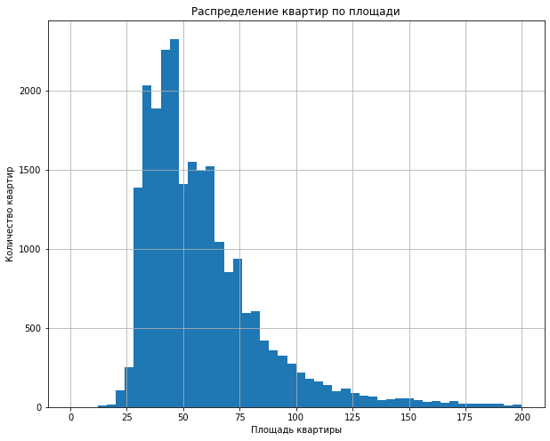

```python
# Гистограмма площади
df['total_area'].hist(bins=50, range=(0, 200),  figsize=(10, 8))
plt.title('Распределение квартир по площади')
plt.xlabel('Площадь квартиры')
plt.ylabel('Количество квартир');
```

В целом, гистограмма площади стремится к нормальному распределению, наибольшее количество квартир находится в диапазоне от 30 до 60 квадратных метров.

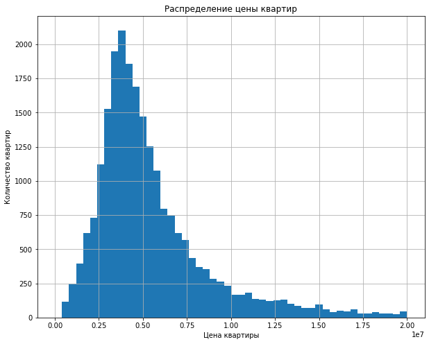

```python
# Гистограмма цены квартиры
df['last_price'].hist(bins=50, range=(0, 20000000),  figsize=(10, 8))
plt.title('Распределение цены квартир')
plt.xlabel('Цена квартиры')
plt.ylabel('Количество квартир');
```

Аналогичная ситуация наблюдается и с ценой квартиры. Гистограмма похожа на нормальное распределение с длинным хвостом высоких значений и падением в ноль слева от пиковых значений. Большинство квартир находятся в диапазоне от 2 до 7 млн. рублей.

Для того, чтобы разбить гистограмму количества комнат на корректное число корзин, для начала посмотрим диапазон значений, который встречается в столбце `rooms`

```python
df['rooms'].value_counts()
```

```
1     8004
2     7897
3     5779
4     1172
5      325
0      194
6      104
7       59
8       12
9        8
10       3
11       2
14       2
15       1
19       1
16       1
12       1
Name: rooms, dtype: int64
```

Мы выяснили, что диапазон комнат - от 0 до 19, соответственно укажем в гистограмме 20 корзин

[figure not shown]

```python
# Гистограмма количества комнат
df['rooms'].hist(bins=20, range=(0, 19), figsize=(10, 8))
plt.title('Распределение квартир по количеству комнат')
plt.xlabel('Количество комнат')
plt.ylabel('Количество квартир');
```

Гистограмма здесь также похожа на ождидаемое распределение. Большинство квартир - 1 и 2-х комнатные, чуть реже встречаются 3-х комнатные. Падения в ноль слева не наблюдается т.к. нулем комнат в таблице отмечены квартиры-студии.

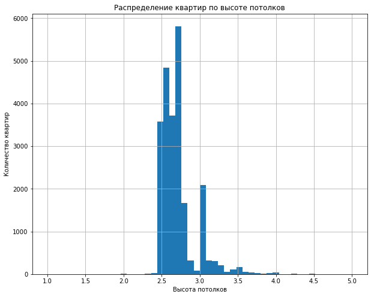

```python
# Гистограмма высоты потолков
df['ceiling_height'].hist(bins=50, range=(1, 5), figsize=(10, 8))
plt.title('Распределение квартир по высоте потолков')
plt.xlabel('Высота потолков')
plt.ylabel('Количество квартир');
```

Мы видим, что большинство квартир, как и предполагалось, вписываются в стандартные нормативы высоты потолков от 2,5 до 2,7 метров. При этом стоит отметить, что на графике также присутствует еще один пик в районе 3 метров.

**Вывод**

В рамках этого шага были исследованы показатели площади, цены, числа комнат и высоты потолков квартир, представленных в таблице. Было обнаружено следующее:

- Наибольшее количество квартир находится в диапазоне от 30 до 60 квадратных метров.
- Цена большинства квартир находятся в диапазоне от 2 до 7 млн. рублей.
- Большинство квартир - 1 и 2-х комнатные, чуть реже встречаются 3-х комнатные.
- Большинство квартир, вписываются в стандартные нормативы высоты потолков от 2,5 до 2,7 метров. При этом на графике присутствует еще один пик в районе 3 метров (возможно связан с массовой застройкой жилья определенного типа).

## 4.2 Исследование времени продажи квартиры

К содержанию

```python
df['days_exposition'].describe()
```

```
count    20394.000000
mean       180.741395
std        219.732782
min          1.000000
25%         45.000000
50%         95.000000
75%        231.000000
max       1580.000000
Name: days_exposition, dtype: float64
```

Среднее время продажи - 180 дней, медианное значение - 95

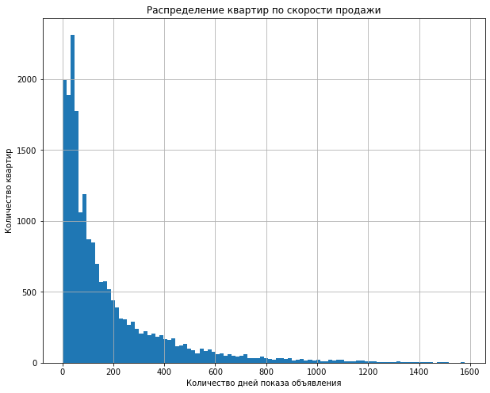

```python
df['days_exposition'].hist(bins=100,  figsize=(10, 8))
plt.title('Распределение квартир по скорости продажи')
plt.xlabel('Количество дней показа объявления')
plt.ylabel('Количество квартир');
```

Как видно из графика, большинство продаж укладывается в полгода. Встречаются и чрезвычайно долгие продажи - вплоть до 4 лет.

Рассмотрим поближе промежуток времени, за который квартиру успевают продать чаще всего - первые 200 дней.

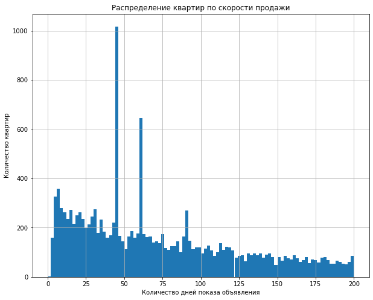

```python
df['days_exposition'].hist(bins=100, range=(0, 200),  figsize=(10, 8))
plt.title('Распределение квартир по скорости продажи')
plt.xlabel('Количество дней показа объявления')
plt.ylabel('Количество квартир');
```

Мы видим, что активный рост числа продаж начинается примерно через неделю после размещения объявления.

Также на графике присутствуют несколько аномальных пиков, которые выбиваются из общего тренда на постепенное снижение количества продаваемых со временем квартир - это 45, 60 и 90 дней.

**Вывод**

Отталкиваясь от данных графика, а также значений полученных при помощи метода `describe()` можно сделать следующие **выводы:**

## 4.3 Удаление редких и выбивающихся значений

К содержанию

Для того, чтобы научиться определять рыночную стоимость объектов недвижимости необходимо обнаружить закономерности и взаимосвязи между различными характеристиками продаваемых квартир. Для этого необходимо избавиться от потенциальных выбросов, которые могут исказить результаты исследования. Для поиска аномальных значений воспользуемся диаграммой размаха и методом `describe()`

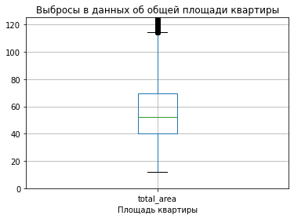

```python
# Поиск выбросов выбивающихся значений в данных об общей площади квартиры
df.boxplot('total_area')
plt.ylim(0, 125)
plt.title('Выбросы в данных об общей площади квартиры')
plt.xlabel('Площадь квартиры');
```

```python
df['total_area'].describe()
```

```
count    23565.000000
mean        60.322824
std         35.657060
min         12.000000
25%         40.000000
50%         52.000000
75%         69.700000
max        900.000000
Name: total_area, dtype: float64
```

Мы видим, что нижняя граница потенциальных выбросов находится в районе 12, а верхняя в районе 115 квадратных метров. Стоимость квартир, не входящих в диапазон нормальных значений, может определяться дополнительными факторами, которые не нашли свое отражение в исходном датафрейме. Например слишком маленькие квартиры могут быть бывшими "нормальными" квартирами по факту переделанными в студии или комнатами в коммуналке (довольно частое явление для Петербурга), а слишком большие - могут являться объектами элитной недвижимости, ценообразование которых также может отличаться от обычных квартир.

Для того, чтобы подобные редкие и выбивающиеся значения не исказили итоговые результаты исследования, создадим новую таблицу, в которую попадут строки с отфильтрованными значениями.

```python
# Создание датафрейма с фильтрацией жилой площади
good_df = df.query('12 <= total_area <= 115')
```

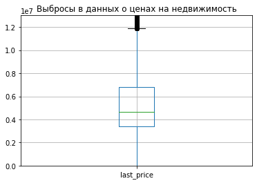

```python
# Поиск выбросов выбивающихся значений среди цен на недвижимость
df.boxplot('last_price')
plt.ylim(0, 13000000)
plt.title('Выбросы в данных о ценах на недвижимость');
```

```python
df['last_price'].describe()
```

```
count    2.356500e+04
mean     6.540058e+06
std      1.091093e+07
min      1.219000e+04
25%      3.400000e+06
50%      4.646000e+06
75%      6.790000e+06
max      7.630000e+08
Name: last_price, dtype: float64
```

По аналогии с жилой площадью чрезмерно высокие значения цены на недвижимость также не очень подходят для установления параметров ценообразования для наиболее типичных квартир.

Поэтому отфлильтруем уже новую таблицу по верхней границе диаграммы размаха стоимости квартир - составляющей примерно 12 млн. рублей.

```python
good_df = good_df.query('last_price <= 12000000')
```

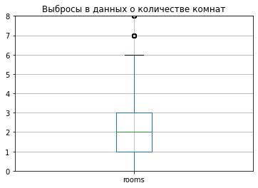

```python
# Поиск выбросов выбивающихся значений в данных о количестве комнат
df.boxplot('rooms')
plt.ylim(0, 8)
plt.title('Выбросы в данных о количестве комнат');
```

```python
df['rooms'].describe()
```

```
count    23565.000000
mean         2.070656
std          1.078591
min          0.000000
25%          1.000000
50%          2.000000
75%          3.000000
max         19.000000
Name: rooms, dtype: float64
```

Слишком большое количнество комнат также не характерно для среднестатистической квартиры. Согласно диаграмме подаваляющее большинство квартир имеют не более 3 комнат, однако встречаются экземпляры и с 19 комнатами (что вовсе не характерно для жилой недвидимости). Для того, чтобы исключить влияние подобных дворцов на результаты исследования, отфлильтруем квартиры по верхней границе диаграммы размаха - составляющей 6 комнат.

```python
good_df = good_df.query('rooms <= 6')
```

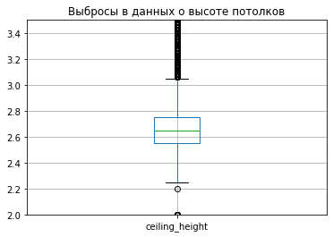

```python
# Поиск выбросов выбивающихся значений в данных о высоте потолков
df.boxplot('ceiling_height')
plt.ylim(2, 3.5)
plt.title('Выбросы в данных о высоте потолков');
```

```python
df['ceiling_height'].describe()
```

```
count    23565.000000
mean         2.734191
std          0.981219
min          1.000000
25%          2.550000
50%          2.650000
75%          2.750000
max        100.000000
Name: ceiling_height, dtype: float64
```

Высота потолков для объектов жилой недвижимости редко превышает 3 с небольшим метра. Однако в таблице встречаются значения и в сто метров. Представляется невозможным определить что это - ошибка или же случайно затесавшийся в датафрейм космодром. Поэтому аналогично предыдущим шагам вновь отфлильтруем таблицу по границам диаграммы размаха.

При этом, учитывая, что по САНПИН высота потолка в жилом помещении не должна быть ниже 2.5 м. возьмем эту отметку в качестве нижней границы

```python
good_df = good_df.query('2.5 <= ceiling_height <= 3.1')
```

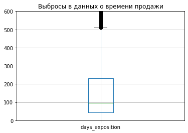

```python
# Поиск выбросов выбивающихся значений в данных о времени продажи
df.boxplot('days_exposition')
plt.ylim(0, 600)
plt.title('Выбросы в данных о времени продажи');
```

```python
df['days_exposition'].describe()
```

```
count    20394.000000
mean       180.741395
std        219.732782
min          1.000000
25%         45.000000
50%         95.000000
75%        231.000000
max       1580.000000
Name: days_exposition, dtype: float64
```

Наконец, отфильтруем столбец с временем продажи квартиры. В данном случае мы видим, что присутствуют чрезвычайно высокие значения, серьезно искажающие выборку. Это можно понять, взглянув на среднее и медиану, которые отличаются почти в 2 раза. Для того, чтобы свести подобные искажения к минимуму, удалим из выборки значения, превышающие верхнюю границу диаграммы размаха

```python
good_df = good_df.query('days_exposition <= 510')
```

**Вывод**

По результатам этого шага был создан новый отфильтрованный датафрейм, который не содержит в себе редких и выбивающихся значений из столбцов `days_exposition`, `total_area`, `rooms`, `ceiling_height` и `last_price`.